# Analysis of Sigma Wage Increase

Alex Kowalski, MIT

7/28/2020

# Summary

The goal of this analysis is to determine if wage increases reduce turnover inside Sigma fulfillment centers. We first examine monthly data at the building level and find that it can be difficult to draw conclusions when multiple trends, like seasonality and building-specific changes, co-occur. We then examine daily data on individual associates from PeopleSoft to see how these workers respond to an increase in wage rates. What is valuable about this second analysis is that it allows us to compare associates in similar places in their employment histories and in similar work environments, thus allowing us to “control” away trends that may obscure our ability to draw any conclusions. *In the end, both examinations support the conclusion that increases in wage rates likely reduce turnover.*

## Building-level analysis

### Overview

We begin by looking at how monthly building-level turnover varies in relation to wage increases. To do this, we simply divide the total number of terminations each month by the total number of part-time and full-time associates employed during that month and analyze if this ratio varies after wages are increased.

To show a change in turnover, we do not need to annualize the turnover rate because we care only about the change in turnover, not the actual level of turnover. The turnover rates used in this analysis may thus appear small relative to the more commonly used annualized rates because the former correspond to the share of associates lost in a given building each month.

Changes in turnover are easy to visualize if we compare buildings that receive a raise with those that do not receive a raise within the same period. In other words, we compare average monthly turnover rates across buildings in the period leading up to and following a raise. The time period is standardized by subtracting the date of the wage increase from the current month so that zero equals the date of the raise; months leading up to the raise have negative values and months following it have positive values. By standardizing the dates, we are taking one step toward netting out the effects of seasonality because we are comparing different buildings at the same point in time relative when some received raise.

You can see the results of such an analysis in the below figure. For simplicity’s sake, this figure only shows what happened when a raise was offered to a broad group of buildings on 10/29/2017.

Anchorage is excluded here and in all analyses because of its size.

### Findings

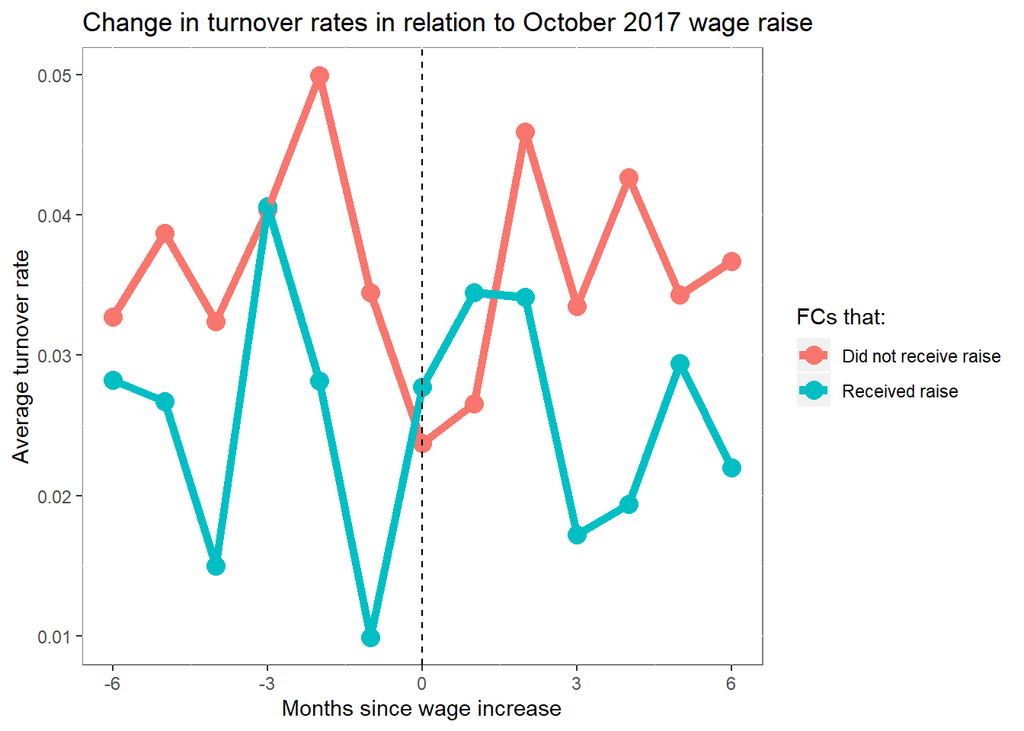

What should stand out at first is that it is hard to discern any major differences between those buildings that receive a wage increase and those that do not. Ideally the green and red lines would mirror each other before the raise, left of zero, and diverge after the raise. If you squint, it looks like the green line, which represents those receiving a raise, trends lower.

And this conclusion is likely right. When we perform a regression analysis on this data, we notice that turnover rates are marginally lower in buildings that receive wage increases in the months after the wage increase.

But we do not have much confidence in this estimate. There are too many things going on that prevent us from accepting it without further analyses. The most obvious issue is that we are lumping together buildings and thus comparing averages derived from multiple buildings when, in reality, buildings may be experiencing very different trends. Another issue is that turnover jumps around month-to-month, which is obvious in the above figure. A third issue is that because we are looking at buildings, we may miss that certain departments react differently to raises than others. A final issue is that because we are looking at monthly data, we may miss changes that occur closer to the date of the wage increase before fading away. We can overcome some of these challenges by working with data on individual associates, as in the next section.

## Associate-level analysis

### Overview

We now turn examining individual associate’s responses to a wage increase. We do this by looking at individual employment histories in the PeopleSoft database. With this data, we can ask: do associates who receive a wage increase stay longer than those who do not? In other words, does a raise increase tenure?

There are several virtues to this approach that are worth mentioning. One, because we are looking at individuals, we are able to compare a given associate both to her coworkers and to those who work in different buildings during the same timeframe. This helps overcome seasonal or building-specific trends, stripping out influences shared within a given FC or across the network that might encourage all associates to exit. For example, if turnover is higher in warmer months, we can compare those who exit to those who do not in the same warm month. Similarly, if a single building experiences a disruption, we can compare those within that building who exit to those who do not even though both groups face the same challenging circumstance. Two, because we are using PeopleSoft, we have additional data that we can use to control for other important determinants of turnover. The most important is time: initially we expect shorter tenure to drive turnover before longer tenure becomes associated with greater retention.

The one downside with this approach is that it becomes harder to easily communicate our findings. Visuals like the one above are no longer straightforwardly constructed. Instead, we rely mostly on printed tables. I will try to explain the tables so that the findings can be shared with others.

We employ what is called a “survival analysis” because it was developed to help medical researchers determine the likelihood that a health event occurs. In our case, the event is job exit. The idea behind this method is that every day, we look at all the associates employed inside the FCs and ask: who is going to exit today? We then look at those who exited and those who stayed to see if there are systematic differences between these groups. Finally, we average across all the days we have analyzed to see if these systematic differences hold over time. The differences we consider in the current analysis are: receiving a raise, tenure, past status as a temp worker, seasonality, and building-specific events.

As you can see, this kind of analysis can handle many moving pieces. Hence, it becomes easier to study multiple wage increases simultaneously. We thus look at *all* wage hikes from 2017 to 2019. At the same time, because we have more data, the analysis becomes more computationally intensive. For this reason, we focus initally only on associates working in bulk and breakpack because they experience the most turnover. But we can expand the sample in the future.

Kronos IDs: 1832, 1835, 1836, 1855, 1840, 1845, 1850, 1852, 1885, 1848

### Findings

The below table displays the results of the survival analysis. It starts with the most simple analysis in the left column–asking only if we can detect a general impact from wage raises on turnover–before gradually adding in control variables.

To understand this table, it helps to recognize that the numbers it contains show the change in the likelihood of job exit when we “flip on” each of the variables listed in the leftmost column. The variable we care most about is “Receives a raise.” This variable is switched on in the days after an associates get a raise. Hence, the number accompanying this variable corresponds to the relative likelihood that the associate will exit once they receive a raise compared to the likelihood that those who have not receive a raise at that time will leave. The asterisks next to these numbers represent our confidence in these estimates. Three stars means we are very confident; no stars means we can’t conclude there is any effect.

| Likelihood of job exit post wage raise |  |  |  |
| --- | --- | --- | --- |
|  | Model 1 | Model 2 | Model 3 |
| Receives a raise | -29%$^{***}$ | -26%$^{***}$ | -33%$^{***}$ |
| Tenure (in months) |  | -1%$^{***}$ | -1%$^{***}$ |
| Likely temp to perm? |  | -53%$^{***}$ | -50%$^{***}$ |
| Breakpack? |  | 3% | 3% |
| Adjusts for seasonality? | N | N | Y |
| Adjust for building-specific histories? | N | N | Y |

What you should take away is that *raises do appear to reduce turnover* among breakpack and bulk pickers. When we add all controls in Model 3, we see that getting a raise reduces the likelihood of exit by about 33% compared to an associate who does not get a raise, all else equal. This is true when we account for tenure and seasonal as well building differences in turnover rates.

The other variables may be interesting as well. Increased tenure is associated with lower rates of turnover: tenure here is measured in months, so the table indicates that every month an associate stays on the job, they are about 1% less likely to quit. Associates who started as temps are much less likely to leave their jobs than those hired directly. Finally, there is little evidence that exit behavior differs substantively between breakpack and bulk pickers.

# Summary and future directions

In sum, the evidence thus far leads us to conclude that wage raises do reduce turnover. We draw this conclusion by comparing associates who receive an increase in wage rates to otherwise similar associates who do not receive one.

This is only the initial cut. Several future analysis, time permiting, could increase our confidence in this finding. These include:

- Assessing how long the raise impact lasts. Presumably, the raise will have it’s biggest impact in the first several months before associates become accustomed to it.
- Seeing if different kinds of associates are more or less impacted by the raise than others. One group that stands out is recent hires and new associates who have made it past their 90 days. We can look to see if exit behavior differs among these groups and others.
- Quantifying whether the size of the raise matters. There are at least two interesting questions here. One, do larger raises have bigger impacts? Right now, we are treating all raises as the same. Second, does the impact depend on the associate’s base pay? If the raise is large relative to their typical earnings, we might expect it to have a bigger effect on exit.
- Seeing if there are differences in voluntary versus involuntary turnover rates.
- Digging deeper into questions of correlation versus causation. The associate-level analysis gives us some notion of causation because it allows us to compare those who did receive a raise to those who did not, but there more convincing techniques exist. The best evidence would be experimental–randomly give some associates a raise–but we can also employ more sophisticated statistical techniques.